# ESPM 137, Lab 1: Introduction to R, Part II

September 3, 2020

#! This lab is worth 5 points and is due on September 11 at 5:00pm. !#

## Overview

Last week, we explored different object types in R and how to write loops and conditional statements. This week, we’ll learn a few more generally useful conditionals and then how to work with some simple GIS data (rasters and shapefiles).

### Set up the R session

Set the options for Rmarkdown.

### All, Any, Which…

Sometimes we want to find out if a certain value exists in a vector (or other object). We have a few options for value matching, including all(), any(), and which(). Let’s see how they work. First, let’s create a vector of numbers to test against.

```r
big.vec <- seq(from = 1, to = 45, by = 3)
```

Now let’s create a shorter vector and use the all() function to test whether all elements of the small vector can be found in the big vector. To see whether a value is contained in another set, we use the %in% operator.

```r
small.vec <- c(1, 44, 7, 9, 16, 7)
all(small.vec %in% big.vec) # Are all the values in small.vec found in big.vec
```

```
## [1] FALSE
```

R evaluates this statement (are all the values in small.vec found in big.vec?) and finds that they are not, so it reports the statement as FALSE.

So, not all of the elements in small.vec are contained in big.vec, but are any of them? We can test this using the any() function.

```r
any(small.vec %in% big.vec)
```

```
## [1] TRUE
```

In this case, the condition is TRUE.

So, some of the numbers in small.vec are found in big.vec, but what if we want to know which ones? For this, we can use the which() function.

```r
which(small.vec %in% big.vec)
```

```
## [1] 1 3 5 6
```

Note than which tells us which elements of the vector fulfill the condition. i.e. These are indices for the elements in the vector, not the numbers themselves.

We can also test the values of the elements in vectors using comparison operators: == (equal to), != (not equal to), < (less than), <= (less than or equal to), > (greater than), and >= (greater than or equal to).

### Question 1 (1 pt)

In the box below, identify (1) which elements in small.vec are equal to 7, and then (2) whether all elements are less than 44.

```r
which(small.vec == 7)
```

```
## [1] 3 6
```

```r
all(small.vec < 44)
```

```
## [1] FALSE
```

### Random Numbers

Generating random numbers can be really useful (for instance, when we want to run simulations), and R gives us convenient functions for generating random numbers from several probability distributions. Two that we will use in this class are the normal distribution and the uniform distribution.

To generate random numbers from a normal distribution, we can use the rnorm() function.

rnorm(n, mean = 0, sd = 1) n: number of observations to generate mean: mean value of the distribution sd: standard deviation of the distribution

Let’s generate a vector of 10 random numbers with a mean of 1 and standard deviation of 1.

```r
rnorm(10, mean = 1, sd = 1)
```

```
##  [1]  1.4302521  2.7228509  2.7575325  0.1093410  2.4415939 -0.4966561
##  [7]  0.3518443  1.4189323  0.7887099 -0.1052582
```

We can also, of course, assign the output of the random number functions to an object. Here, we’ll create a vector of 1000 random numbers drawn from a normal distribution with a mean of 0 and standard deviation of 1.

```r
nums <- rnorm(1000, mean = 0, sd = 1)
```

We can use the hist() function to plot a histogram for the values in the vector. This can be useful for visualizing the distribution of values in an object.

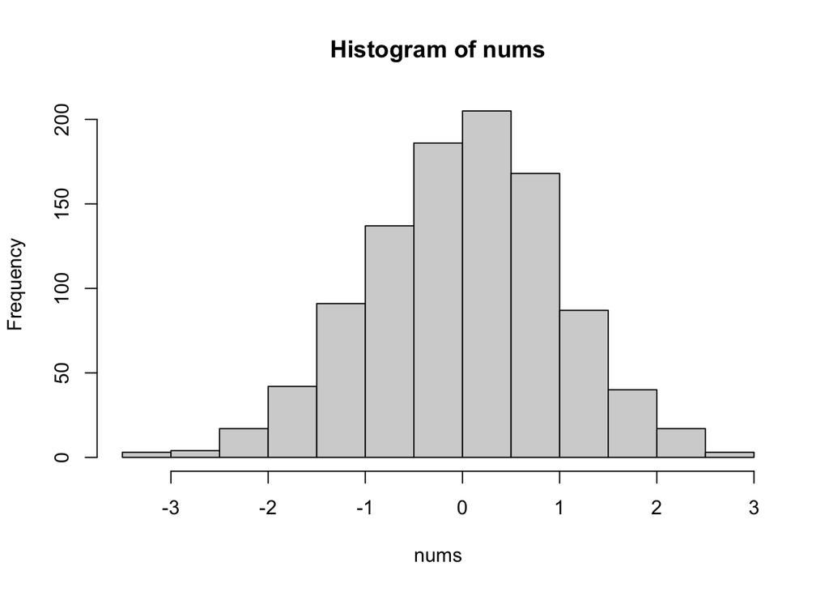

```r
hist(nums)
```

To generate random numbers from a uniform distribution, we can use the runif() function.

runif(n, min = 0, max = 1) n: number of observations to generate min: lower limit of the distribution max: upper limit of the distribution

### Question 2 (1 pt)

In the box below, generate a vector of 100 random numbers drawn from a uniform distribution ranging from 0 to 50. Then, to make sure you have declared the arguments correctly, test whether all of the numbers in the vector are less than or equal to 50.

```r
uninums <- runif(n = 100, min = 0, max = 50)
all(uninums <= 50)
```

```
## [1] TRUE
```

## Using R for GIS

Now that we have a handle on basic R objects and functions, let’s start looking into how we can use R for GIS. Today, we’ll explore shapefile and raster data and perform some basic statistics.

First, we need to load the required packages. This code chunk checks for the R packages we need and installs them if they are missing. You can run it without making any changes.

### Shapefiles

The rgdal package includes a function, readOGR(), that allows us to read in shapefiles. Here, we’ll read in a shapefile that contains the boundaries for the counties in California.

```r
shp <- readOGR(dsn = "County", layer = "CaliforniaCounty", stringsAsFactors = FALSE)
shp
```

```
## class       : SpatialPolygonsDataFrame
## features    : 58
## extent      : -124.482, -114.1312, 32.52883, 42.00952  (xmin, xmax, ymin, ymax)
## crs         : +proj=longlat +datum=NAD83 +no_defs
## variables   : 17
## names       : STATEFP, COUNTYFP, COUNTYNS, GEOID,    NAME,       NAMELSAD, LSAD, CLASSFP, MTFCC, CSAFP, CBSAFP, METDIVFP, FUNCSTAT,       ALAND,    AWATER, ...
## min values  :      06,      001, 00277273, 06001, Alameda, Alameda County,   06,      H1, G4020,   260,  12540,    31084,        A, 10146978597, 104169243, ...
## max values  :      06,      115, 02054176, 06115,    Yuba,    Yuba County,   06,      H6, G4020,   488,  49700,    42044,        C,  9778203379, 962952585, ...
```

As you can see, looking at the information for the shp object we created tells us a lot about it. It tells us that it’s a Spatial Polygons Data Frame object (a special class of GIS objects in R), it tells us how many polygons (features) are in the shapefile, and it gives us its extent and projection (coordinate reference system).

We can also get the extent and projection using the extent() and projection() functions.

```r
extent(shp)
```

```
## class      : Extent
## xmin       : -124.482
## xmax       : -114.1312
## ymin       : 32.52883
## ymax       : 42.00952
```

```r
projection(shp)
```

```
## [1] "+proj=longlat +datum=NAD83 +no_defs"
```

And we can get the number of features/polygons using the nrow() function. In this case, each polygon corresponds to a county.

```r
nrow(shp)
```

```
## [1] 58
```

Some complex object classes in R have data structured into different slots. We can access these slots use the @ character.

```r
head(shp@data) # show us what's in the data slot
```

```
##   STATEFP COUNTYFP COUNTYNS GEOID            NAME               NAMELSAD LSAD
## 0      06      107 00277318 06107          Tulare          Tulare County   06
## 1      06      009 01675885 06009       Calaveras       Calaveras County   06
## 2      06      047 00277288 06047          Merced          Merced County   06
## 3      06      079 00277304 06079 San Luis Obispo San Luis Obispo County   06
## 4      06      097 01657246 06097          Sonoma          Sonoma County   06
## 5      06      041 00277285 06041           Marin           Marin County   06
##   CLASSFP MTFCC CSAFP CBSAFP METDIVFP FUNCSTAT       ALAND    AWATER
## 0      H1 G4020  <NA>  47300     <NA>        A 12494707314  37391604
## 1      H1 G4020  <NA>   <NA>     <NA>        A  2641820029  43810423
## 2      H1 G4020  <NA>  32900     <NA>        A  5011554680 112760479
## 3      H1 G4020  <NA>  42020     <NA>        A  8543230300 820974619
## 4      H1 G4020   488  42220     <NA>        A  4081430061 497530414
## 5      H1 G4020   488  41860    41884        A  1347585499 797420416
##      INTPTLAT     INTPTLON
## 0 +36.2288317 -118.7810618
## 1 +38.1846184 -120.5593996
## 2 +37.1948063 -120.7228019
## 3 +35.3852268 -120.4475409
## 4 +38.5250258 -122.9376050
## 5 +38.0518169 -122.7459738
```

Above, you can see that the ‘data’ slot just holds a data.frame (which we saw earlier), and each row in the data frame holds the information for one county (each of these rows is one of the Polygons in the Spatial Polygons Data Frame). You can also see that one of the variables in the data frame is called NAME. We can retrieve the elements in NAME by calling them like we did with the data frame above.

```r
shp@data$NAME
```

```
##  [1] "Tulare"          "Calaveras"       "Merced"          "San Luis Obispo"
##  [5] "Sonoma"          "Marin"           "Humboldt"        "Mono"
##  [9] "Del Norte"       "Colusa"          "Alameda"         "El Dorado"
## [13] "Sutter"          "Kings"           "Sierra"          "Lassen"
## [17] "Lake"            "Tehama"          "San Francisco"   "Alpine"
## [21] "Madera"          "Sacramento"      "Santa Barbara"   "Plumas"
## [25] "Modoc"           "Solano"          "Ventura"         "Santa Cruz"
## [29] "Yuba"            "Tuolumne"        "Napa"            "Siskiyou"
## [33] "Placer"          "Glenn"           "Trinity"         "Inyo"
## [37] "San Benito"      "Monterey"        "San Diego"       "Mariposa"
## [41] "Nevada"          "Mendocino"       "Yolo"            "Imperial"
## [45] "Stanislaus"      "Kern"            "Contra Costa"    "Fresno"
## [49] "Santa Clara"     "San Mateo"       "Butte"           "San Joaquin"
## [53] "Amador"          "Shasta"          "Riverside"       "Los Angeles"
## [57] "Orange"          "San Bernardino"
```

### Question 3 (0.5 pts)

In the box below, identify which of the polygons (i.e. rows in the data frame) corresponds to Alameda County. We did this with numbers in vectors in the first part of this lab exercise, and we can do the same with a character string (but remember to enclose the string in quotation marks). Assign this number to an object named alameda_num.

```r
alameda_num <- which(shp@data$NAMELSAD == "Alameda County")
```

If we want to subset the Spatial Polygons Data Frame to retrieve just the polygon for Alameda County, we could do so by using the index for the row number that corresponds to Alameda.

```r
shp[alameda_num, ] # retrieve the row/polygon corresponding to Alameda county from the data frame
```

```
## class       : SpatialPolygonsDataFrame
## features    : 1
## extent      : -122.3738, -121.4692, 37.45439, 37.90582  (xmin, xmax, ymin, ymax)
## crs         : +proj=longlat +datum=NAD83 +no_defs
## variables   : 17
## names       : STATEFP, COUNTYFP, COUNTYNS, GEOID,    NAME,       NAMELSAD, LSAD, CLASSFP, MTFCC, CSAFP, CBSAFP, METDIVFP, FUNCSTAT,      ALAND,    AWATER, ...
## value       :      06,      001, 01675839, 06001, Alameda, Alameda County,   06,      H1, G4020,   488,  41860,    36084,        A, 1914046027, 213184599, ...
```

### Rasters

Next, let’s load a digital elevation model (DEM) in the form of a raster. This raster includes the elevation for each cell on our landscape.

```r
DEM <- raster("elevation.tif") # read in a digital elevation model (DEM) raster
DEM
```

```
## class      : RasterLayer
## dimensions : 58, 62, 3596  (nrow, ncol, ncell)
## resolution : 0.1666667, 0.1666667  (x, y)
## extent     : -124.5, -114.1667, 32.5, 42.16667  (xmin, xmax, ymin, ymax)
## crs        : +proj=longlat +datum=WGS84 +no_defs
## source     : /Users/rosskalter/Desktop/School/Berkeley/Fall 2020/ESPM 137/Lab2/elevation.tif
## names      : elevation
## values     : -71, 3418  (min, max)
```

What is the projection (coord. ref.) of this raster? Does it match the projection of our shapefile? It doesn’t, but we won’t worry about that today. However, in the future, be very careful about this; it’s important to make sure that the data you are analyzing have the same geographic projection, otherwise the spatial locations on one dataset won’t be the same as the other.

Now, plot the DEM and add the county shapefile as an overlay to see what we’re working with.

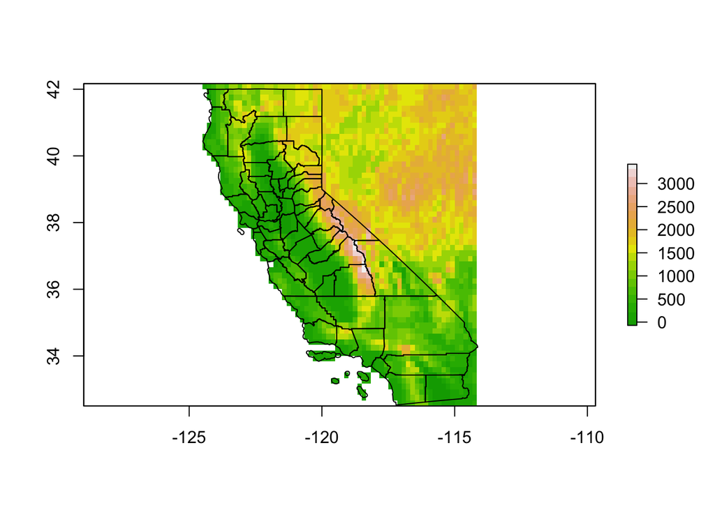

```r
plot(DEM, col=terrain.colors(20))
plot(shp, add = TRUE) # using 'add = TRUE' allows us to overlay the shapefile; if we used 'add = FALSE' then it would replace the previously plotted DEM
```

Now, let’s get the elevation for every cell in each of the counties. We do this using the extract() function from the raster package. (This may take a few minutes to run.)

```r
elev <- extract(DEM, shp)
```

```
## Warning in .local(x, y, ...): Transforming SpatialPolygons to the CRS of the
## Raster
```

```r
head(elev) # This is a long list, so the head() functions just shows us the first few entries.
```

```
## [[1]]
##  [1]  224  584 1136 2030 3002 3354   91  110  207  587 1678 2938 2854 3047   85
## [16]  101  166  599 1388 2331 2290 2683   72   93  127  273  938 1938 2018 2455
## [31] 2215   65   92  145  289  895 1769 1949 2180 2104
##
## [[2]]
##  [1] 1170 1632 2093  327  622  976   94  378  446  657  292
##
## [[3]]
##  [1] 129  24  41  58 104  87  25  30  40  57  84 163  47  30  35 416 231  73 605
##
## [[4]]
##  [1] 381 467 329 265 350 500 516 216 416 364 323 400 529 104 320 402 555 562 638
## [20] 741 162 166 294 451 676 677 651 779  79 263 426 709 797 759
##
## [[5]]
##  [1] 175 222 387 313 276 646 201 290 314 146 152 160 125  53 284  88 114  71
##
## [[6]]
## [1]  44  66  71 153 117   5 202 180
```

You’ll notice the warning message (in red) that the projections for our shapefile and raster don’t match. Fortunately, the extract() functions corrects for this mismatch automatically.

Next, let’s calculate the average elevation for each county based on the extracted values. One of R’s built-in math functions is mean(), which finds the mean average for a set of values. We could write a loop that goes through each slice in the list of extracted elevation values (each slice corresponds to a county), but R provides some helper functions that make this process even easier. So, here, we can just use the lapply() function, which stands for ‘list apply’ and applies a given function to every entry in a list.

lapply(X, FUN, …) X: a vector or an expression object. FUN: the function to be applied to each element of X …: option arguments to FUN

Below, we’ll also supply the ‘na.rm = TRUE’ argument, which gets passed along to the mean() function. This tells the function to ignore values that are listed as NA. These come up because some parts of the county polygons aren’t covered by a raster cell.

```r
avg_elev <- lapply(elev, mean, na.rm=TRUE) # lapply() applies the mean() function to every slice in elev.
head(avg_elev)
```

```
## [[1]]
## [1] 1277.55
##
## [[2]]
## [1] 789.7273
##
## [[3]]
## [1] 119.9474
##
## [[4]]
## [1] 449.0294
##
## [[5]]
## [1] 223.1667
##
## [[6]]
## [1] 104.75
```

We don’t need this information as a list any more, so let’s convert it to a vector instead. We can do that using the unlist() function.

```r
avg_elev <- unlist(avg_elev)
avg_elev
```

```
##  [1] 1277.55000  789.72727  119.94737  449.02941  223.16667  104.75000
##  [7]  477.15000 2406.53333  618.69231  238.00000  238.62500 1251.05556
## [13]   21.83333  134.23077 1774.57143 1633.71111  706.69231  710.25000
## [19]   46.00000 2361.83333  888.42857   33.70000  424.25714 1631.70370
## [25] 1515.82222   57.00000  747.20000  198.71429  394.00000 1799.05263
## [31]  297.12500 1298.92063 1173.00000  397.93750 1157.93548 1297.92473
## [37]  572.00000  432.16667  564.47727 1096.53333 1228.00000  528.38889
## [43]   98.27273  128.06667  185.40000  723.03896  127.00000 1071.06897
## [49]  362.83333  158.57143  564.35294   48.09091  983.50000  873.35135
## [55]  551.29091  613.72727  192.44444  810.82812
```

Now, let’s use the area() function to calculate the area of each county, based on the shapefile.

```r
county_area <- area(shp)
head(county_area)
```

```
## [1] 12532102997  2685629872  5124315054  9364201559  4578960343  2145006181
```

### Question 4 (0.5 pts)

In the box below, retrieve the area for Alameda County. Recall the index we found for Alameda county a few steps above.

```r
county_area[alameda_num]
```

```
## [1] 2127230718
```

And now let’s try out one of R’s slightly more advanced statistical functions. The lm() function allows us to quickly fit a linear model to our data; that means to conduct a linear regression analysis. Here, we’ll use the tilde (~) operator to specify a formula or equation. e.g. the equation for a line, y = mx + b, would be represented as y ~ mx + b.

```r
reg <- lm(avg_elev ~ county_area) # conduct the linear regression analysis and store the result in reg
summary(reg) # show us the results
```

```
##
## Call:
## lm(formula = avg_elev ~ county_area)
##
## Residuals:
##    Min     1Q Median     3Q    Max
## -641.1 -438.4 -211.6  351.0 1740.3
##
## Coefficients:
##              Estimate Std. Error t value Pr(>|t|)
## (Intercept) 5.922e+02  1.032e+02   5.737 4.06e-07 ***
## county_area 1.524e-08  9.524e-09   1.601    0.115
## ---
## Signif. codes:  0 '***' 0.001 '**' 0.01 '*' 0.05 '.' 0.1 ' ' 1
##
## Residual standard error: 580.4 on 56 degrees of freedom
## Multiple R-squared:  0.04374,    Adjusted R-squared:  0.02667
## F-statistic: 2.562 on 1 and 56 DF,  p-value: 0.1151
```

### Question 5 (1 pt)

Is the average elevation of the counties significantly correlated with their areas? Should we expect them to be? If they were, can you think of a good ecological reason that would explain the correlation? >> Based off the results, the average elevation of the counties does not seem to be significantly correlated with their areas because the p-value is large (0.1151)

### Question 6a (0.5 pts)

In the box below: 1) Calculate the maximum elevation for each county and assign these values to an object named max_elev. You can use the max() function to get the maximum value from an array. You can do this using either the lapply() function or using a loop. If you want extra practice, try doing it both ways.  
2) Test whether maximum elevation is correlated with average elevation.

```r
# Part 1
max_elev <- lapply(elev, max, na.rm=TRUE) # lapply() applies the max() function to every slice in elev.
max_elev <- unlist(max_elev)

#Part 2
new_reg <- lm(max_elev ~ avg_elev) # conduct the linear regression analysis and store the result in new_reg
summary(new_reg) # show us the results
```

```
##
## Call:
## lm(formula = max_elev ~ avg_elev)
##
## Residuals:
##     Min      1Q  Median      3Q     Max
## -947.03 -338.97  -56.59  257.18 1474.16
##
## Coefficients:
##             Estimate Std. Error t value Pr(>|t|)
## (Intercept) 492.3742   101.7779   4.838 1.07e-05 ***
## avg_elev      1.3552     0.1114  12.169  < 2e-16 ***
## ---
## Signif. codes:  0 '***' 0.001 '**' 0.01 '*' 0.05 '.' 0.1 ' ' 1
##
## Residual standard error: 494.7 on 56 degrees of freedom
## Multiple R-squared:  0.7256, Adjusted R-squared:  0.7207
## F-statistic: 148.1 on 1 and 56 DF,  p-value: < 2.2e-16
```

### Question 6b (0.5 pts)

Are maximum and average elevation significantly correlated? Does this result make sense? >> Yes this makes sense! Maximum and average elevation for a county are significantly correlated to one another. How neat!

### Question 7 (0 pts)

Ok, this is the last task for this lab exercise, and it’s a bit of a challenge. It’s not worth any points, so don’t worry if you can’t get it to work right now, but it’s good practice to try anyway. In the box below: 1) Calculate the average (mean) maximum elevation across all of the counties (the mean of all counties’ max elevations). 2) If a county has a maximum elevation lower than the mean, add the name of the county to a vector named lower; if it has a higher maximum elevation than the mean, add its name to a vector named higher. 3) Check the total lengths of your vectors to make sure all counties were added to one or the other.

```r
mean_elev <- mean(max_elev)
lower_ind <- which(max_elev < mean_elev)
higher_ind <- which(max_elev > mean_elev)
```

### The End

That’s all for today! Hopefully R is starting to feel accessible to you. If there’s anything that didn’t quite make sense today, then talk with your GSI!